# STAT 37810 Final Project #2: Gibbs Sampling

Yingzhao Li & Linlin Wu

Nov. 1st, 2016

## 1 Algorithm and Implementation

The initial values of x and y takes on a random number from (0,B), where B is a known positive constant.

Since the conditional distribution of x|y is given as $p(x|y)=ye^{-yx}$, the cumulative density function of the conditional distribution is $F(x|y)=\int_0^x ye^{-yx}dx$. Using inverse transform sampling, we first generate a random number u from $U=Unif(0,1)$. Then
$$u=\frac {\int_0^x ye^{-yx}dx}{\int_0^B ye^{-yx}dx}=\frac {1-e^{-xy}}{1-e^{-By}}.$$
Solving for x, we can get
$$x=-\frac {ln(1-u+ue^{-B*y})}{y}.$$

Similary, using inverse transform sampling and generating a random number v from $V=Unif(0,1)$, we have
$$y=-\frac {ln(1-v+ve^{-B*x})}{x}.$$

Then, we store the results into the *chain*. The first column of *M* stores the iterations from 1 to T. The second column of *M* stores the values of x for each iteration and the third column of *M* stores the values of y for each iteration.

Finally, this function returns the complete matrix *M*.

We implement the alogrithm for B=5 and for sample sizes T = 500, 5000, 50000, with thin = 10.

The algorithm and implementation in Python are shown as follows:

```python
import matplotlib.pyplot as plt
import numpy as np
from numpy import *
import random, math
from math import *
from random import *
def gibbs(T, B, thin):
    M = zeros((T, 3))
    x = uniform(0, B)
    y = uniform(0, B)
    print "Iter  x  y"
    for i in range(T):
        for j in range(thin):
            u = random()
            x = -log(1 - u + u * exp(-B * y)) / y
            v = random()
            y = -log(1 - v + v * exp(-B * x)) / x
        M[i, 0] = i + 1
        M[i, 1] = x
        M[i, 2] = y
    return M

print gibbs(T = 500, B = 5, thin = 10)
print gibbs(T = 5000, B = 5, thin = 10)
print gibbs(T = 50000, B = 5, thin = 10)
```

```
## Iter  x  y
## [[  1.00000000e+00   4.63642926e-01   2.75099904e+00]
##  [  2.00000000e+00   1.16707901e-01   1.89379331e+00]
##  [  3.00000000e+00   1.00120150e+00   3.26820375e+00]
##  ...,
##  [  4.98000000e+02   2.75226239e-01   1.69883315e+00]
##  [  4.99000000e+02   3.02751160e-01   2.50875737e+00]
##  [  5.00000000e+02   3.01724500e-01   1.50309714e+00]]
## Iter  x  y
## [[  1.00000000e+00   3.21227788e+00   5.65492829e-01]
##  [  2.00000000e+00   2.91923553e-01   4.31217708e-01]
##  [  3.00000000e+00   6.82090865e-01   7.03273204e-01]
##  ...,
##  [  4.99800000e+03   2.84162413e-01   9.95521642e-01]
##  [  4.99900000e+03   4.18435770e-01   1.26032449e+00]
##  [  5.00000000e+03   8.73069888e-01   1.10007990e+00]]
## Iter  x  y
## [[  1.00000000e+00   8.43807084e-01   1.06770637e+00]
##  [  2.00000000e+00   3.02728060e-01   2.27524061e-01]
##  [  3.00000000e+00   4.55096719e-01   2.62306395e+00]
##  ...,
##  [  4.99980000e+04   4.44700588e+00   3.54595343e-02]
##  [  4.99990000e+04   4.20878002e-01   4.80628251e-01]
##  [  5.00000000e+04   1.92584004e+00   1.58093918e-01]]
```

## 2 Histograms of values for x

For B=5 and for sample sizes T = 500, 5000, 50000, the histograms of values for x are shown as follows.

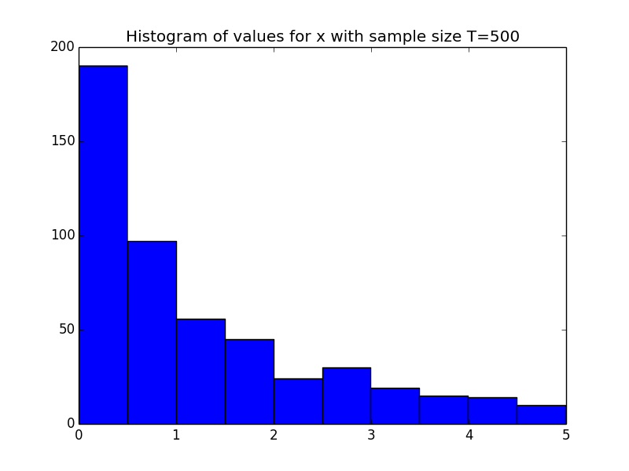

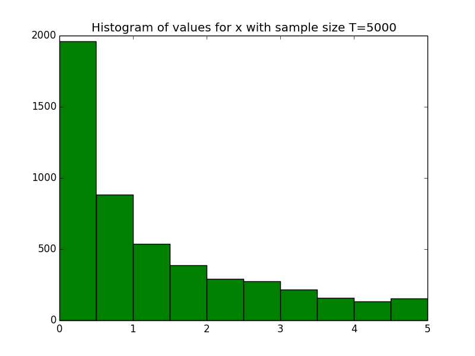

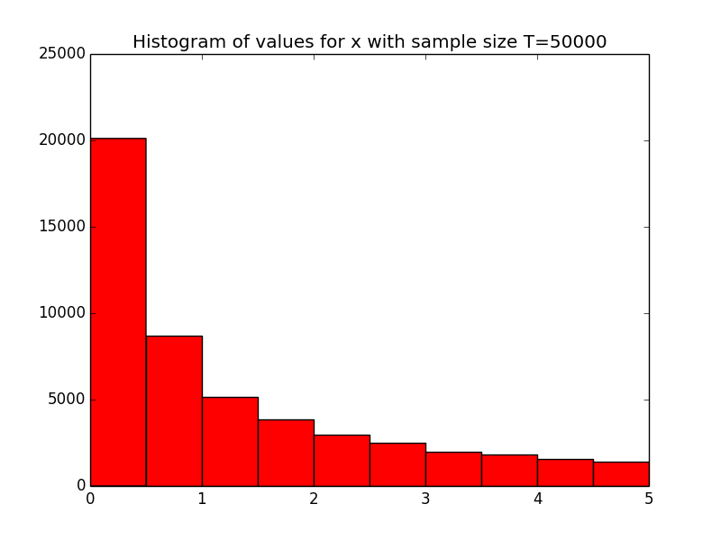

## 3 Estimate of the expectation of X

```
## 1.23714212304
## 1.27903135915
## 1.26246756324
```

Simulation based approximations provide straightforward methods of calculating the moments of the marginal distributions. By using the 500, 5000 and 50000 samples from the sampler, we can estimate that the expectation of X, $E_{p(X)}[X]$, is around 1.26.